# Bulk RNA Analysis

Analysis

Wes Horton

2026-05-27

```r
### Load Utils package
if (!require("wrh.rUtils")) remotes::install_github("weshorton/wrh.rUtils")

library(data.table)
library(DESeq2)
library(projectR)
library(CoGAPS)
library(wrh.rUtils)
library(ggplot2)
library(ggpubr)
library(RColorBrewer)
library(pheatmap)
```

# Overview

Load CoGAPS patterns generated from single-cell RNAseq expression data, project them onto human bulk RNAseq data, and evaluate patterns as well as genes of interest with respect to clinically-relevant grouping variables.

Required inputs:

1. Bulk RNAseq expression matrix - rows are genes, columns are samples
2. Metadata - rows are samples, must match expression matrix columns. Colummns include any plotting/grouping variables desired
3. CoGAPS pattern file
4. Immune Activation reference
5. Human mouse mapping

Initial project ([Roussos Torres](https://www.nature.com/articles/s43018-024-00729-w)), has response groups evaluated by RECIST and measurements across multiple time points, which will be the main parameters (see below).

## Set Parameters

Depending on the project, set the analysis parameters.

1. `projName_v` - name of project for plot titles
2. `geneCol_v` - the name of the column in the counts data.table that contains gene names. Becomes rownames when converting to data.frame
3. `idCol_v` - the name of the column in the metadata data.table that matches the colnames of the counts table. This becomes rownames when converting to data.frame
4. `timeCol_v` - the name of the column in the metadata that contains the time designations. Roussos Torres uses `Timepoint`
5. `timeLevels_v` - the factor levels for timeCol_v in order of earliest to latest timepoint. Roussos Torres uses `Baseline`, `Post_RunIn`, `Week_8`
6. `groupCol_v` - the name of the column in the metadata that contains the group designations. Roussos Torres uses `RECIST`
7. `groupLevels_v` - the factor levels for groupCol_v in order of “less-treated”/“worse response” to “more-treated”/“better response”. Roussos Torres uses `NonResponder` and `Responder`
8. `genes_v` - gene names of genes to be tested
9. `patternCols_v` - names of the CoGAPS patterns. Should just be Pattern_1 through Pattern_10
10. `shapeCol_v` - optional metadata column that controls shape in plots. Roussos Torres uses `Subtype`

```r
projName_v <- "Roussos Torres"

geneCol_v <- "gene"
idCol_v <- "ID"

timeCol_v <- "Timepoint"
#timeLevels_v <- c("Baseline", "Post_RunIn", "Week_8")
timeLevels_v <- c("Baseline", "Week_8")

groupCol_v <- "RECIST"
groupLevels_v <- c("NonResponder", "Responder")

shapeCol_v <- "Subtype"

genes_v <- c("MIF", "CD74", "EGFR")
patternCols_v <- paste0("Pattern_", 1:10)
```

# Helper Functions

```r
getCorStat <- function(x, y, method_v = "pearson") {
  #' Get Corr Stat
  #' @details run correlation on provided vectors and format output
  #' @param x first vector
  #' @param y second vector
  #' @param method_v method to pass to cor.test(). Default is "pearson"
  #' @export

  ### Correlation only works with sufficient observations.
  ### Return blank if fewer than 3 actual paired values in x and y
  keep_v <- complete.cases(x, y)
  if (sum(keep_v) < 3) {
    warning("Fewer than 3 non-missing paired values in provided vectors.\n")
    return(data.frame(n = sum(keep_v), correlation = NA_real_, p_value = NA_real_))
  }

  ### Run test
  fit <- cor.test(x[keep_v], y[keep_v], method = method_v)

  ### Build output
  out_df <- data.frame("n" = sum(keep_v),
                       "correlation" = unname(fit$estimate),
                       "p_value" = fit$p.value)

  ### Return
  return(out_df)

} # getCorStat
```

# Load Data

The data should already be wrangled into a usable format before loading here.

Set the main directory as well as the sub-directory for the input files and outputs

```r
baseDir_v <- "~/my_tool_repos/humanValidation/"
dataDir_v <- mkdir(baseDir_v, "inputs")
baseOutDir_v <- mkdir(baseDir_v, "outputs")
```

Specify file names for counts and meta

```r
countName_v <- "cleanCounts.csv"
metaName_v <- "cleanMetadata.csv"
```

Read them in (data.table)

```r
counts_dt <- fread(file.path(dataDir_v, countName_v))
meta_dt <- fread(file.path(dataDir_v, metaName_v))
```

# Subset

If `timeLevels_v` or `groupLevels_v` don’t contain all the possible values in the metadata, have to subset before doing anything

```r
# Subset metadata
meta_dt <- meta_dt[get(timeCol_v) %in% timeLevels_v,]
meta_dt <- meta_dt[get(groupCol_v) %in% groupLevels_v,]

# Subset data
counts_dt <- counts_dt[,mget(c(geneCol_v, meta_dt[[idCol_v]]))]

# Check
if (!identical(setdiff(colnames(counts_dt), geneCol_v), meta_dt[[idCol_v]])) stop("Messed up subset. Data columns and meta rows don't match.\n")
```

# DESeq

```r
# Change to data.frame for DESeq
countData_df <- convertDFT(counts_dt, col_v = geneCol_v)
colData_df <- convertDFT(meta_dt, col_v = idCol_v)

# Factorize
colData_df[[timeCol_v]] <- factor(colData_df[[timeCol_v]], levels = timeLevels_v)
colData_df[[groupCol_v]] <- factor(colData_df[[groupCol_v]], levels = groupLevels_v)

# Build design
design_form <- as.formula(paste("~", timeCol_v, "*", groupCol_v))

# Create DESeq Object
dds <- DESeqDataSetFromMatrix(countData = countData_df,
                              colData = colData_df,
                              design = design_form)

# Get vst data
vstData <- assay(vst(dds))

# Filter out rows with no variance (~650 genes)
vstData <- vstData[apply(vstData, 1, sd) > 0,]
```

# Project CoGAPS Patterns

We have 10 CoGAPS Patterns generated from the B cell cluster of single-cell RNAseq data.  
Project these mouse-derived B cell patterns into the human bulk data.

```r
# Read in patterns and gene-mapping
load(file.path(dataDir_v, "cBCellgres10.Rda"))
humanGenesConv <- readRDS(file.path(dataDir_v, "HumanMouseMap_mart.rds"))

# Project
  # One row per CoGAPS pattern
  # one column per idCol_v value
prRNA <- projectR(data = as.matrix(vstData),
                  dataNames = rownames(vstData),
                  loadings = getAmplitudeMatrix(cg),
                  loadingsNames = humanGenesConv[rownames(getAmplitudeMatrix(cg))],
                  full = TRUE)
```

```
## [1] "7754 row names matched between data and loadings"
## [1] "Updated dimension of data: 7754 21"
```

```r
# Transpose and merge with meta
prRNA_dt <- merge(myT(prRNA$projection, newName_v = idCol_v), meta_dt, by = idCol_v, sort = F)

# Re-factorize
prRNA_dt[[timeCol_v]] <- factor(prRNA_dt[[timeCol_v]], levels = timeLevels_v)
prRNA_dt[[groupCol_v]] <- factor(prRNA_dt[[groupCol_v]], levels = groupLevels_v)
```

# Add Genes of interest

```r
# Get genes
tmp_df <- vstData[rownames(vstData) %in% genes_v,]

# Merge
prRNA_dt <- merge(prRNA_dt, myT(tmp_df, newName_v = idCol_v), by = idCol_v)
```

# Compare Group differences within each Timepoint - Pattern

For each CoGAPS pattern, plot groups, split by timepoint.

Instead of facetting by timepoint, make one plot per so they can be combined variously.

```r
boxDir_v <- mkdir(baseOutDir_v, "patternBoxplot")
sigDir_v <- mkdir(boxDir_v, "significant")
insigDir_v <- mkdir(boxDir_v, "notSignificant")
```

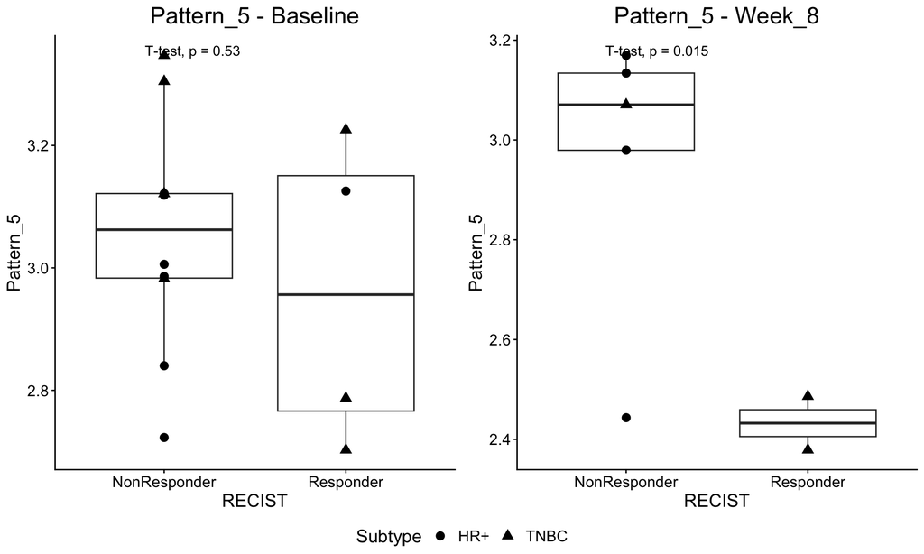

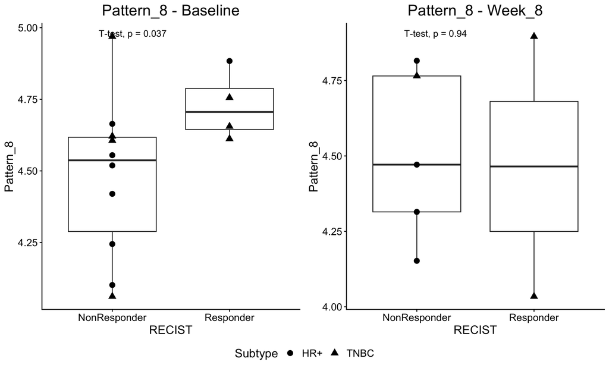

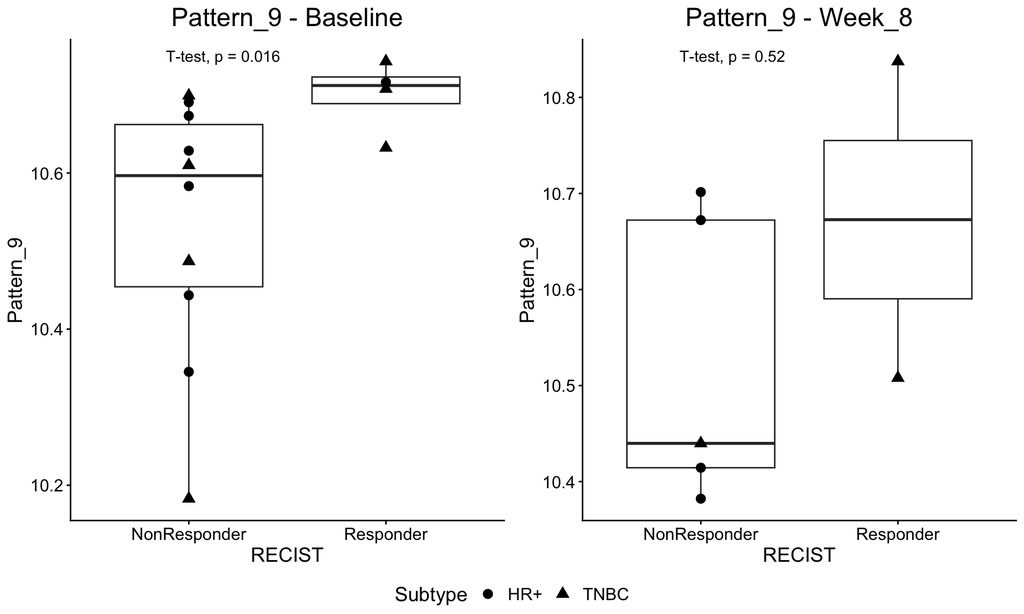

```r
# Run for each Pattern
results_lsdt <- list()
for (i in 1:length(patternCols_v)) {

  # Get info
  currPattern_v <- patternCols_v[i]
  currFormula_v <- as.formula(paste(currPattern_v, "~", groupCol_v))

  # Run for each time
  currBox_lsgg <- currResults_lsdt <- list()
  for (j in 1:length(timeLevels_v)) {

    # Get info
    currTime_v <- timeLevels_v[j]
    currData_dt <- prRNA_dt[get(timeCol_v) == currTime_v,]

    # Make base plot
    currBox_gg <- ggplot(currData_dt, aes(x = !!sym(groupCol_v), y = !!sym(currPattern_v))) +
      geom_boxplot() +
      stat_compare_means(method = "t.test") +
      ggtitle(paste0(currPattern_v, " - ", currTime_v)) +
      my_theme() +
      theme(legend.position = "bottom")

    # Add points
    if (is.null(shapeCol_v)) {
      currBox_gg <- currBox_gg + geom_point(size = 3)
    } else {
      currBox_gg <- currBox_gg + geom_point(aes(shape = !!sym(shapeCol_v)), size = 3)
    }

    # Get results
    currResults_dt <- as.data.table(compare_means(formula = currFormula_v, data = currData_dt, method = "t.test"))

    # Add plot and results to lists
    currBox_lsgg[[currTime_v]] <- currBox_gg
    currResults_lsdt[[currTime_v]] <- currResults_dt

    # Get directory based on p-value
    currDir_v <- ifelse(currResults_dt$p.format < 0.05, sigDir_v, insigDir_v)

    # Save plot
    pdf(file = file.path(currDir_v, paste0(currPattern_v, "_", currTime_v, "_compare_", groupCol_v, ".pdf")), width = 5, height = 6)
    print(currBox_gg)
    dev.off()

  } # for j

  # Combine results and add to final list
  currResults_dt <- dtListBind(currResults_lsdt, newName_v = timeCol_v)
  results_lsdt[[currPattern_v]] <- currResults_dt

  # Combine plots
  currCombo_gg <- ggarrange(plotlist = currBox_lsgg, nrow = 1, ncol = length(timeLevels_v), common.legend = T, legend = "bottom")

  # Check significance
  currPvalues_v <- currResults_dt$p.format
  checkSig_v <- (length(which(currPvalues_v < 0.05)) > 0)

  # Get directory based on p-value
  currDir_v <- ifelse(checkSig_v, sigDir_v, insigDir_v)

  # Print based on p-value
  if (checkSig_v) print(currCombo_gg)

  # Save plot
  pdf(file = file.path(currDir_v, paste0(currPattern_v, "_allTimePoints_compare_", groupCol_v, ".pdf")), width = 5*length(timeLevels_v), height = 6)
  print(currCombo_gg)
  dev.off()

} # for i
```

```r
# Combine results and save
results_dt <- do.call(rbind, results_lsdt)
writeCSVorExcel(results_dt, file.path(boxDir_v, paste0("patterns_allTimePoints_compare_", groupCol_v, ".csv")))
```

# Compare Group differences within each Timepoint - Gene

For each gene, plot groups, split by timepoint.

With fewer genes, want them side-by-side

```r
boxDir_v <- mkdir(baseOutDir_v, "geneBoxplot")
sigDir_v <- mkdir(boxDir_v, "significant")
insigDir_v <- mkdir(boxDir_v, "notSignificant")
```

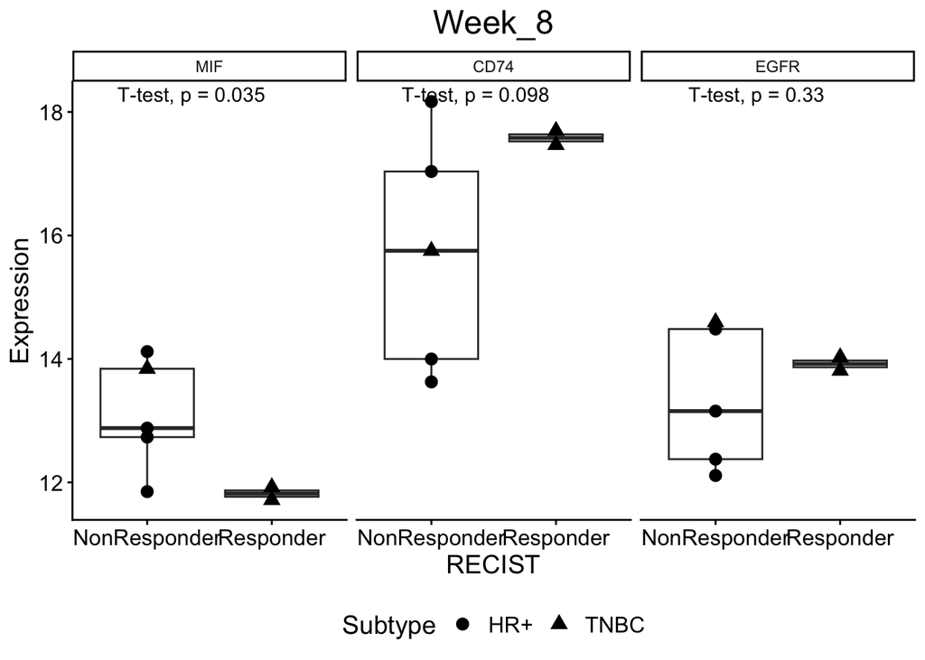

```r
# Melt
prRNA_melt_dt <- melt(prRNA_dt, measure.vars = genes_v, variable.name = geneCol_v, value.name = "Expression")

# Factor
prRNA_melt_dt[[geneCol_v]] <- factor(prRNA_melt_dt[[geneCol_v]], levels = genes_v)

box_lsgg <- results_lsdt <- list()
for (i in 1:length(timeLevels_v)) {

  # Get info
  currTime_v <- timeLevels_v[i]
  currData_dt <- prRNA_melt_dt[get(timeCol_v) == currTime_v,]

  # Make base plot
  currBox_gg <- ggplot(currData_dt, aes(x = !!sym(groupCol_v), y = Expression)) +
    geom_boxplot() +
    facet_wrap(as.formula(paste("~", geneCol_v))) +
    stat_compare_means(method = "t.test") +
    ggtitle(currTime_v) +
    my_theme() +
    theme(legend.position = "bottom")

  # Add points
  if (is.null(shapeCol_v)) {
    currBox_gg <- currBox_gg + geom_point(size = 3)
  } else {
    currBox_gg <- currBox_gg + geom_point(aes(shape = !!sym(shapeCol_v)), size = 3)
  }

  # Get results
  currResults_dt <- as.data.table(compare_means(formula = as.formula(paste0("Expression ~ ", groupCol_v)), data = currData_dt, method = "t.test", group.by = geneCol_v))

  # Add to lists
  box_lsgg[[currTime_v]] <- currBox_gg
  results_lsdt[[currTime_v]] <- currResults_dt

  # Check Significance
  currPvalues_v <- currResults_dt$p.format
  checkSig_v <- (length(which(currPvalues_v < 0.05)) > 0)

  # Get directory based on p-value
  currDir_v <- ifelse(checkSig_v, sigDir_v, insigDir_v)

  # Print based on p-value
  if (checkSig_v) print(currBox_gg)

  # Save
  pdf(file = file.path(currDir_v, paste0("geneExpr_", currTime_v, "_compare_", groupCol_v, ".pdf")), width = 10, height = 6)
  print(currBox_gg)
  dev.off()

}
```

```r
# Combine results
results_dt <- dtListBind(results_lsdt, newName_v = timeCol_v)

# Combine plots
combo_gg <- ggarrange(plotlist = box_lsgg, ncol = 1, nrow = length(timeLevels_v), common.legend = T, legend = "right")

# Check significances
pValues_v <- results_dt$p.format
checkSig_v <- (length(which(pValues_v < 0.05)) > 0)

# Get directory based on p-value
outDir_v <- ifelse(checkSig_v, sigDir_v, insigDir_v)

# Print combo
pdf(file = file.path(outDir_v, paste0("geneExpr_allTimePoints_compare_", groupCol_v, ".pdf")), width = 10, height = 6*length(timeLevels_v))
print(combo_gg)
dev.off()
```

# Correlate Patterns with genes

```r
corrDir_v <- mkdir(baseOutDir_v, "genePatternCorrelation")
```

```r
geneCorr_lsdf <- list()
for (i in 1:length(genes_v)) {

  # Get info
  currGene_v <- genes_v[i]

  tmp_ls <- list()
  for (j in 1:length(timeLevels_v)) {

    # Get info
    currTime_v <- timeLevels_v[j]
    currData_dt <- prRNA_dt[get(timeCol_v) == currTime_v,]

    # Run correlations
    currCorr_lsdf <- lapply(patternCols_v, function(pc_v) {
      df <- cbind(currTime_v, pc_v, currGene_v, getCorStat(x = currData_dt[[pc_v]], y = currData_dt[[currGene_v]]))
      colnames(df) <- c(timeCol_v, "pattern", "metric", "n", "correlation", "p_value")
      return(df)
    })

    # Combine and add
    currCorr_df <- do.call(rbind, currCorr_lsdf)
    tmp_ls[[currTime_v]] <- currCorr_df

  } # for j

  # Combine again
  currCorr_df <- do.call(rbind, tmp_ls)

  # Add to final
  geneCorr_lsdf[[currGene_v]] <- currCorr_df

} # for i

myOpenXWriteWkbk(geneCorr_lsdf, file_v = file.path(corrDir_v, "genePatternCorrelationResults.xlsx"))
```

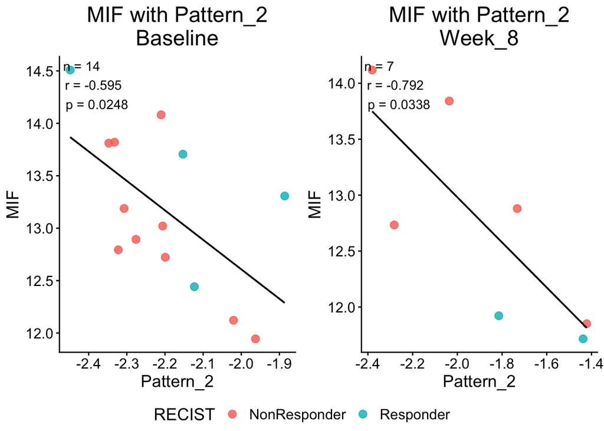

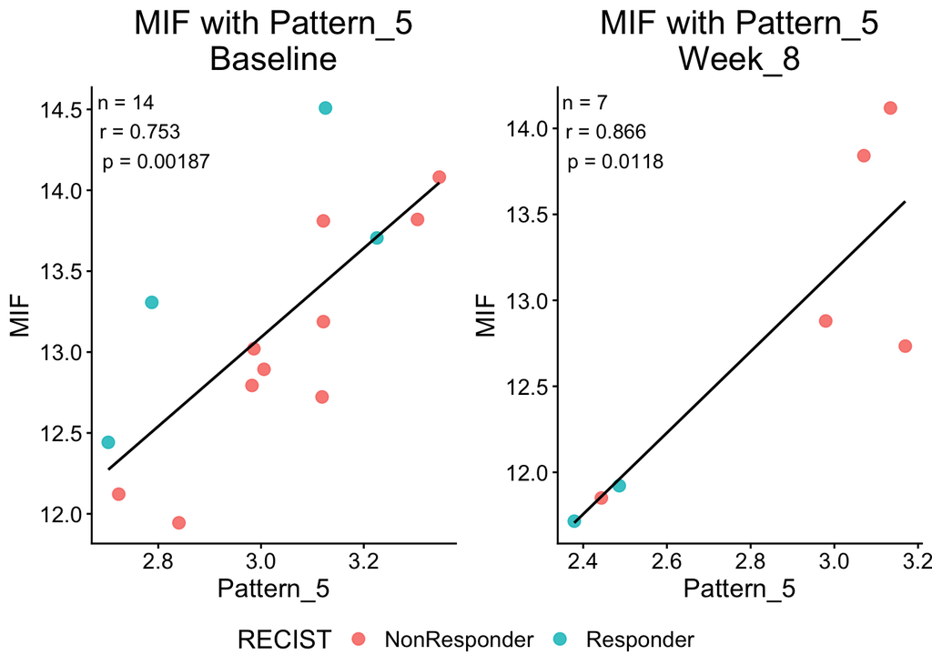

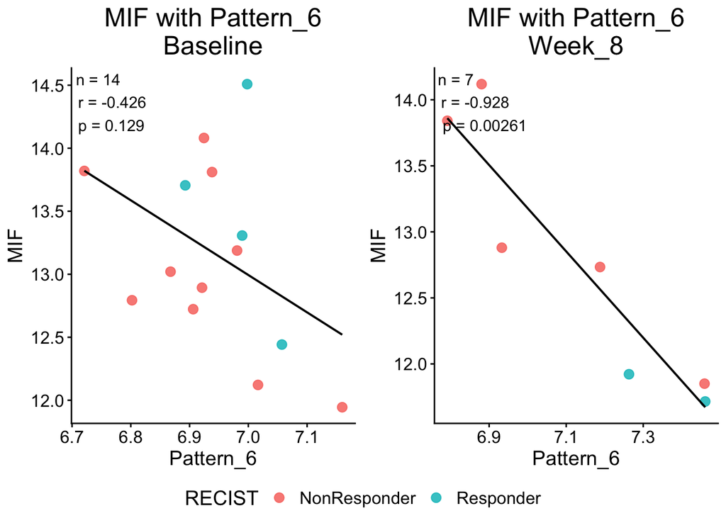

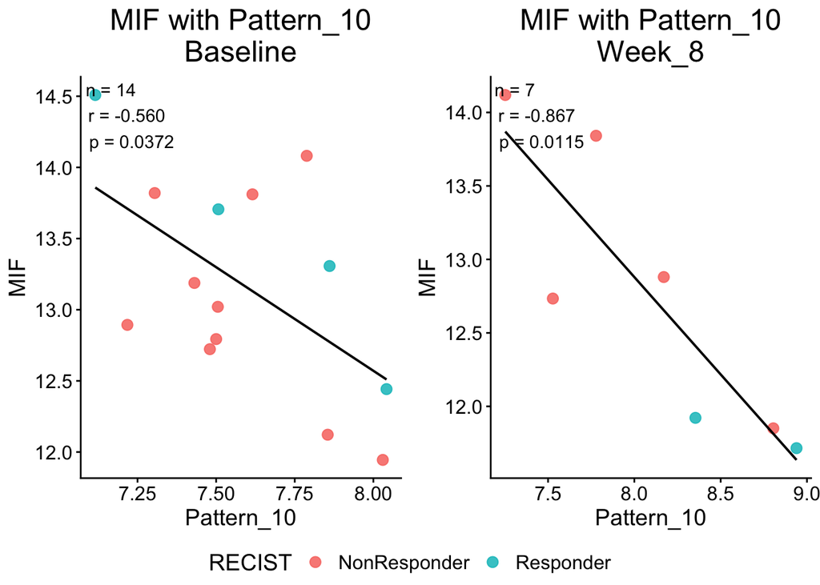

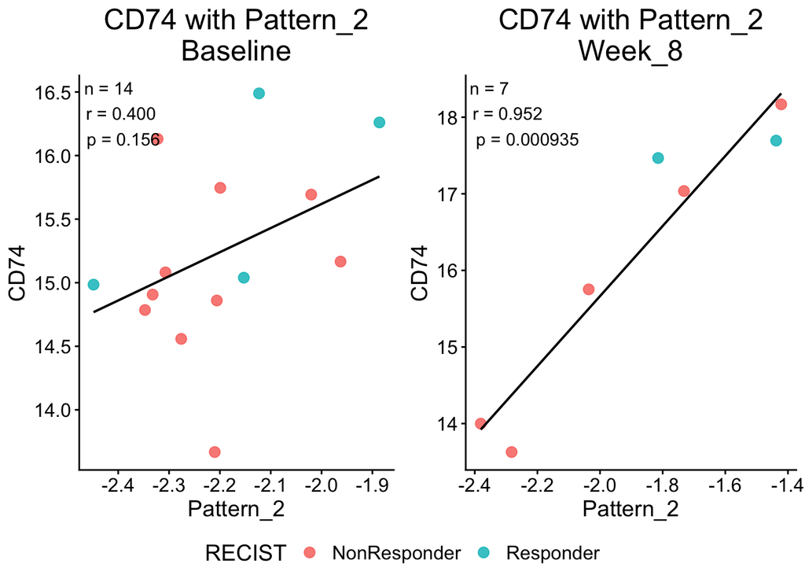

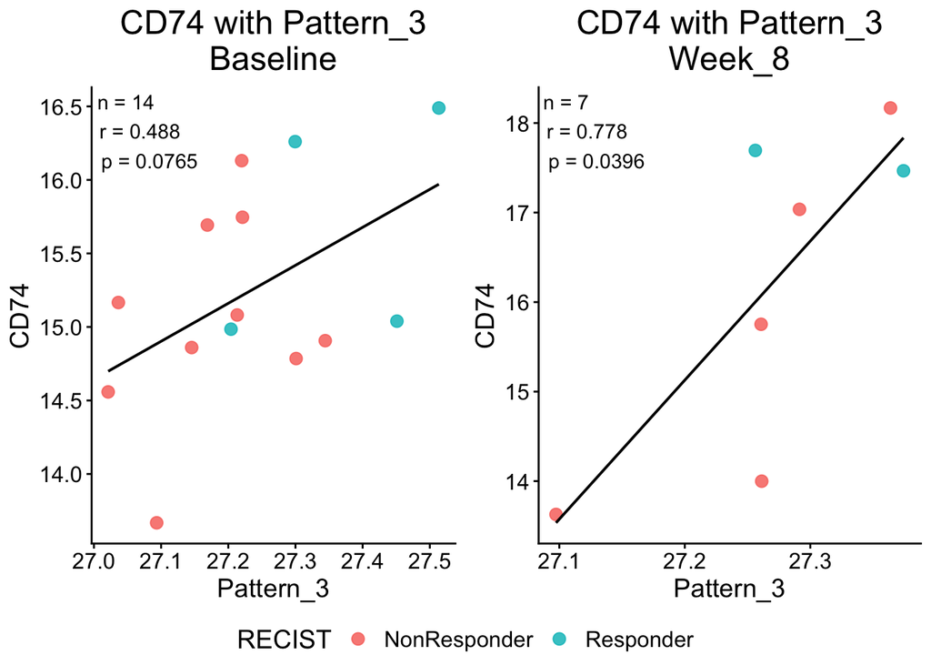

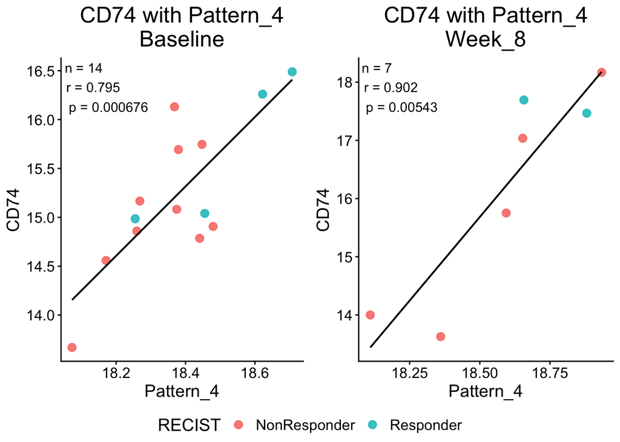

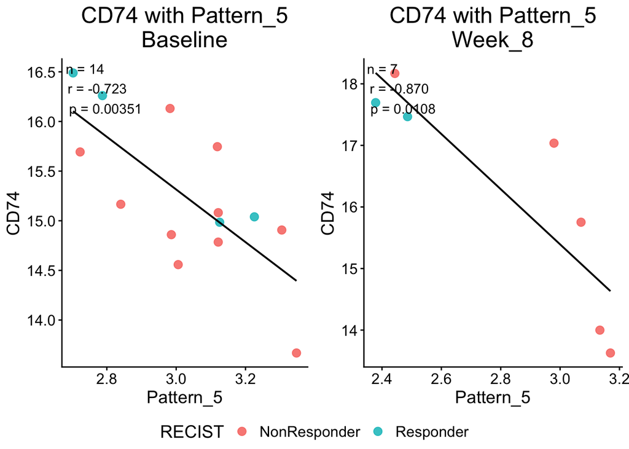

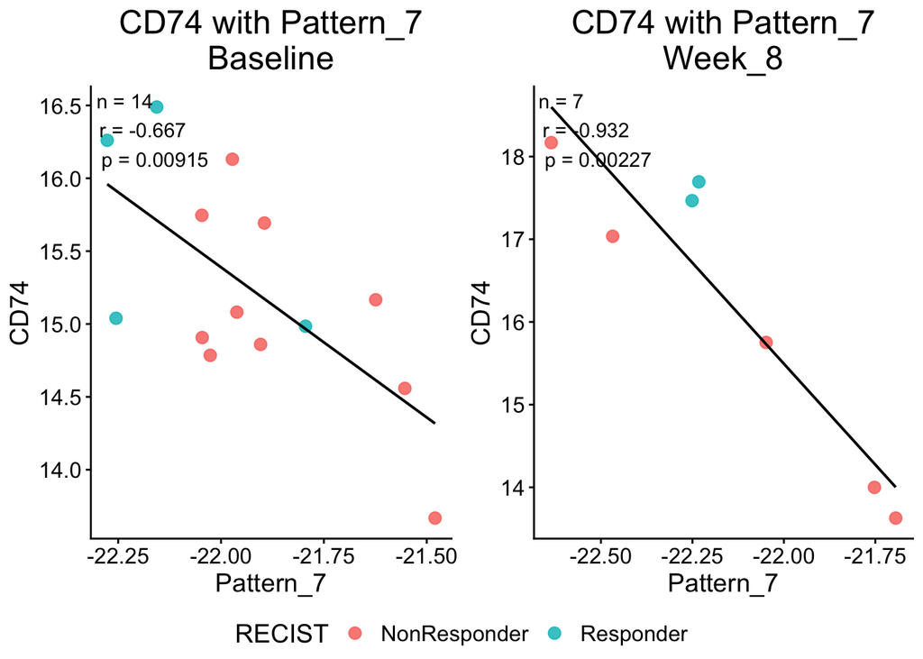

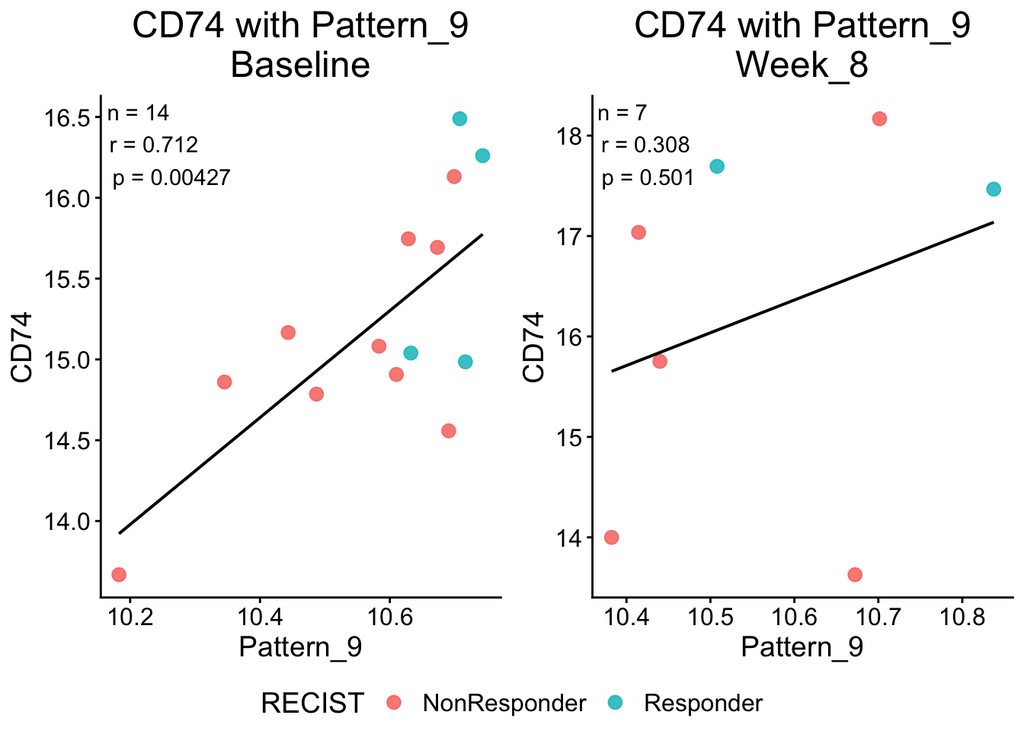

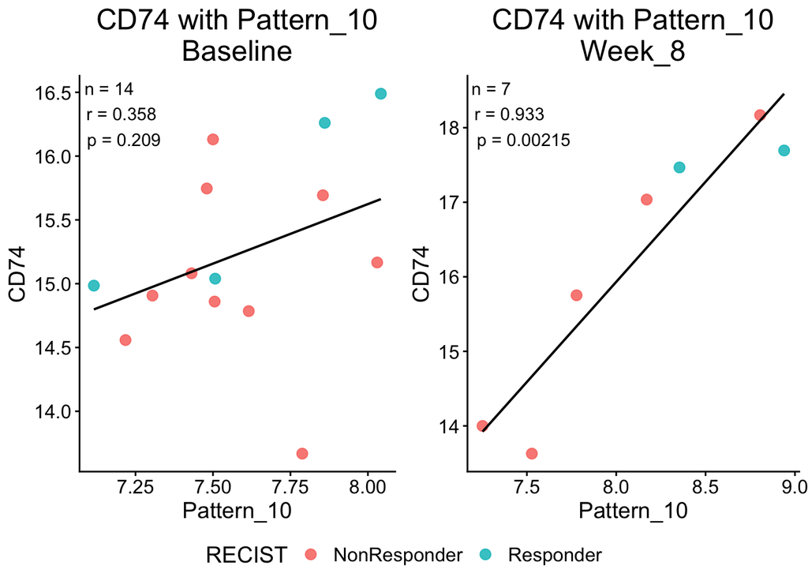

```r
for (i in 1:length(genes_v)) {

  # Get info
  currGene_v <- genes_v[i]
  currCorr_df <- geneCorr_lsdf[[currGene_v]]

  # Output locations
  currOutDir_v <- mkdir(corrDir_v, currGene_v)
  currSigDir_v <- mkdir(currOutDir_v, "significant")
  currInSigDir_v <- mkdir(currOutDir_v, "inSignificant")

  # Subset for significant correlations
  currSigCorr_df <- currCorr_df[currCorr_df$p_value < 0.05,]
  currSigPatterns_v <- unique(currSigCorr_df$pattern)

  # Run per pattern
  for (j in 1:length(patternCols_v)) {

    # Get info
    currPattern_v <- patternCols_v[j]

    # Run per timepoint
    currCorr_lsgg <- list()
    for (k in 1:length(timeLevels_v)) {

      # Get info
      currTime_v <- timeLevels_v[k]
      currData_dt <- prRNA_dt[get(timeCol_v) == currTime_v]
      currRes_df <- currCorr_df[currCorr_df[[timeCol_v]] == currTime_v & currCorr_df$pattern == currPattern_v,]

      # Make label
      currLabel_v <- if (is.na(currRes_df$correlation)) {
        paste("n =", currRes_df$n, "\nr = NA\np = NA")
      } else {
        sprintf("n = %d\nr = %.3f\np = %.3g", currRes_df$n, currRes_df$correlation, currRes_df$p_value)
      } # fi is.na correlation

      # Make plot
      currPlot_gg <- ggplot(currData_dt, aes(x = !!sym(currPattern_v), y = !!sym(currGene_v), color = !!sym(groupCol_v))) +
        geom_point(size = 2.8, alpha = 0.85) +
        geom_smooth(method = "lm", se = FALSE, color = "black", linewidth = 0.7) +
        annotate("text", x = -Inf, y = Inf, label = currLabel_v, hjust = -0.1, vjust = 1.1) +
        my_theme() +
        labs(title = paste0(currGene_v, " with ", currPattern_v, "\n", currTime_v), x = currPattern_v, y = currGene_v)

      # Add to list
      currCorr_lsgg[[currTime_v]] <- currPlot_gg

      # Determine significance
      currSig_v <- currRes_df$p_value < 0.05
      currDir_v <- ifelse(currSig_v, currSigDir_v, currInSigDir_v)

      # Save
      pdf(file = file.path(currDir_v, paste0(currGene_v, "_correlate_", currPattern_v, "_", currTime_v, ".pdf")))
      print(currPlot_gg)
      dev.off()

    } # for k

    # Combine
    currCombo_gg <- ggarrange(plotlist = currCorr_lsgg, nrow = 1, ncol = length(timeLevels_v), common.legend = T, legend = "bottom")

    # Determine significance
    currSig_v <- currPattern_v %in% currSigPatterns_v
    currDir_v <- ifelse(currSig_v, currSigDir_v, currInSigDir_v)

    # Print
    if (currSig_v) print(currCombo_gg)

    # Save
    pdf(file = file.path(currDir_v, paste0(currGene_v, "_correlate_", currPattern_v, "_allTimePoints.pdf")), height = 5, width = 5*length(timeLevels_v))
    print(currCombo_gg)
    dev.off()

  } # for j

} # for i
```

# Heatmap of Immune Activation Genes

```r
# Load data and convert
immActRef_dt <- fread(file.path(dataDir_v, "immuneActivationGenes.csv"))
immActRef_df <- convertDFT(immActRef_dt[, mget(c("Gene", "Category"))], col_v = "Gene")

# Set colors
categoryColors_v <- c("IFN-driven maturation" = "#D8762C", "DC-T cell synapse" = "#2DB08E",
                      "cDC2 (CD4 and Tfh priming)" = "#3076A7", "cDC1 (cross-presentation)" = "#254A65")

heatDir_v <- mkdir(baseOutDir_v, "heatmap")
```

The annotation colors requires manual editing depending on the project.  
Need as input a list with each element’s name as a column in the metadata to be plotted as annotation and the values as the color values (with names)

```r
### Treatment Classifications
treatClass_v <- brewer.pal(7, "Accent")
names(treatClass_v) <- unique(meta_dt$latest_treatment_class)

response_v <- c("NonResponder" = "red", "Responder" = "blue")

timePointColors_v <- brewer.pal(3, "Dark2")
names(timePointColors_v) <- timeLevels_v

subtype_v <- brewer.pal(3, "Paired")[1:2]
names(subtype_v) <- c("TNBC", "HR+")

# Assemble
annColors_lsv <- list("latest_treatment_class" = treatClass_v,
                      "RECIST" = response_v,
                      "Timepoint" = timePointColors_v,
                      "Subtype" = subtype_v,
                      "Category" = categoryColors_v)
```

## All timepoints

```r
# Subset data and sort rows to match immune activation genes
toPlot_df <- vstData[rownames(vstData) %in% immActRef_dt$Gene,]
toPlot_df <- toPlot_df[match(immActRef_dt$Gene, rownames(toPlot_df)),]

# Sort metadata and convert to data.frame
setorderv(meta_dt, cols = c("Timepoint", "RECIST", "Subtype"))
toPlot_meta_df <- convertDFT(meta_dt[,mget(c("ID", "Subtype", "Timepoint", "RECIST", "latest_treatment_class", "Dose_level"))], col_v = "ID")

# Sort data to match metadata order
toPlot_df <- toPlot_df[,rownames(toPlot_meta_df)]
```

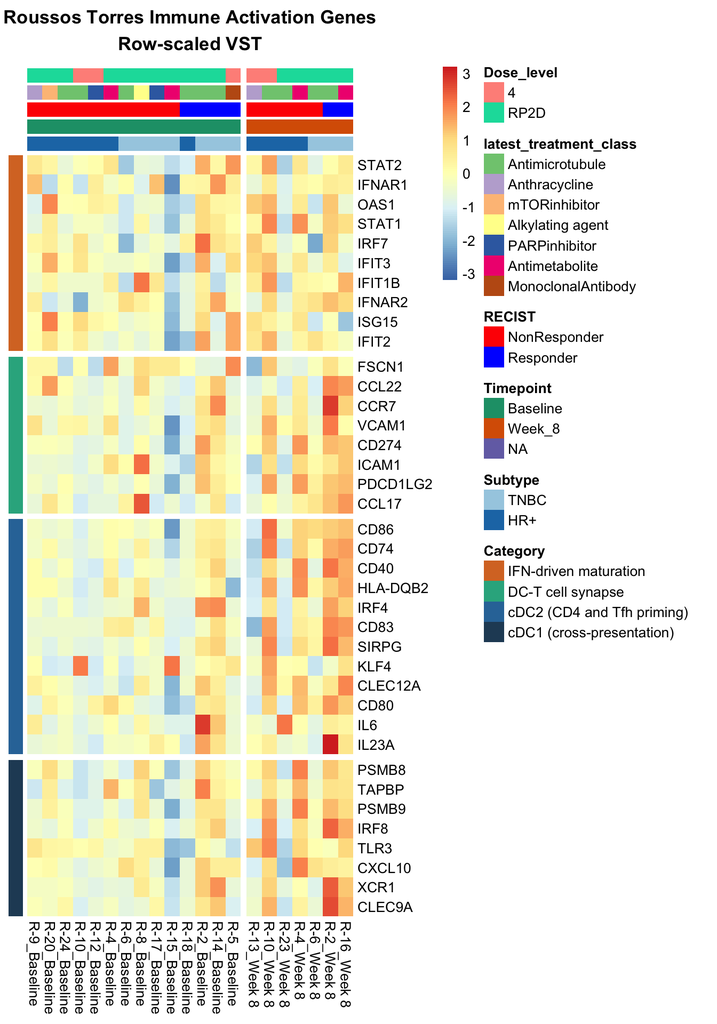

```r
# Make plot - force order
heatmapForceColumnOrder <- pheatmap(mat                  = toPlot_df,
                                    cluster_rows         = F,
                                    show_rownames        = T,
                                    cluster_cols         = F,
                                    show_colnames        = T,
                                    border_color         = NA,
                                    annotation_col       = toPlot_meta_df,
                                    annotation_row       = immActRef_df,
                                    annotation_colors    = annColors_lsv,
                                    cellheight           = NA,
                                    fontsize             = 10,
                                    #gaps_col = c(14, 30), # all tp
                                    gaps_col = c(14), # remove middle time
                                    gaps_row = c(10, 18, 30),
                                    scale                = "row",
                                    annotation_legend    = T,
                                    annotation_names_col = F,
                                    annotation_names_row = F,
                                    silent = F,
                                    main = paste0(projName_v, " Immune Activation Genes\nRow-scaled VST"))
```

```r
pdf(file = file.path(heatDir_v, "forceOrder_immActHeatmap.pdf"), height = 10, width = 7)
grid::grid.draw(heatmapForceColumnOrder)
dev.off()
```

```r
# Make plot
heatmapClusterColumns <- pheatmap(mat                 = toPlot_df,
                                  cluster_rows         = F,
                                  show_rownames        = T,
                                  cluster_cols         = T,
                                  clustering_method = "average",
                                  show_colnames        = T,
                                  border_color         = NA,
                                  annotation_col       = toPlot_meta_df,
                                  annotation_row       = immActRef_df,
                                  annotation_colors    = annColors_lsv,
                                  cellheight           = NA,
                                  fontsize             = 10,
                                  gaps_row = c(10, 18, 30),
                                  scale                = "row",
                                  annotation_legend    = T,
                                  annotation_names_col = F,
                                  annotation_names_row = F,
                                  silent = T,
                                  main = paste0(projName_v, " Immune Activation Genes\nRow-scaled VST"))

pdf(file = file.path(heatDir_v, "columnCluster_immActHeatmap.pdf"), height = 10, width = 7)
grid::grid.draw(heatmapClusterColumns)
dev.off()
```

## Individual timepoints

```r
timePointHeat_ls <- list()
for (tp_v in timeLevels_v) {

  ### Subset for timepoint
  currMeta_df <- toPlot_meta_df[toPlot_meta_df[[timeCol_v]] == tp_v,]
  currData_df <- toPlot_df[,rownames(currMeta_df)]

  ### Make heatmap
  currentHeat <- pheatmap(mat                  = currData_df,
                          cluster_rows         = F,
                          show_rownames        = T,
                          cluster_cols         = T,
                          show_colnames        = T,
                          border_color         = NA,
                          annotation_col       = currMeta_df,
                          annotation_row       = immActRef_df,
                          annotation_colors    = annColors_lsv,
                          cellwidth            = 6,
                          cellheight           = NA,
                          fontsize             = 10,
                          gaps_row             = c(10, 18, 30),
                          scale                = "row",
                          annotation_legend    = T,
                          annotation_names_col = F,
                          annotation_names_row = F,
                          silent               = T,
                          main                 = paste0(projName_v, " - ", tp_v, "\nImmune Activation Genes\nRow-scaled VST"))

  timePointHeat_ls[[tp_v]] <- currentHeat

  pdf(file = file.path(heatDir_v, paste0(tp_v, "_heatmap.pdf")), height = 10, width = 6)
  grid::grid.draw(currentHeat)
  dev.off()

}
```